# Lab1

Hugo

2024-09-12

```r
library(RBGL)
```

```r
library(Rgraphviz)
library(gRain)
```

# 1

Show that multiple runs of the hill-climbing algorithm can return non-equivalent Bayesian network (BN) structures. Explain why this happens. Use the Asia dataset which is included in the bnlearn package. To load the data, run data(“asia”). Recall from the lectures that the concept of non-equivalent BN structures has a precise meaning.

Hint: Check the function hc in the bnlearn package. Note that you can specify the initial structure, the number of random restarts, the score, and the equivalent sample size (a.k.a imaginary sample size) in the BDeu score. You may want to use these options to answer the question. You may also want to use the functions plot, arcs, vstructs, cpdag and all.equal.

```r
library(bnlearn)
library(caret)
data("asia")
```

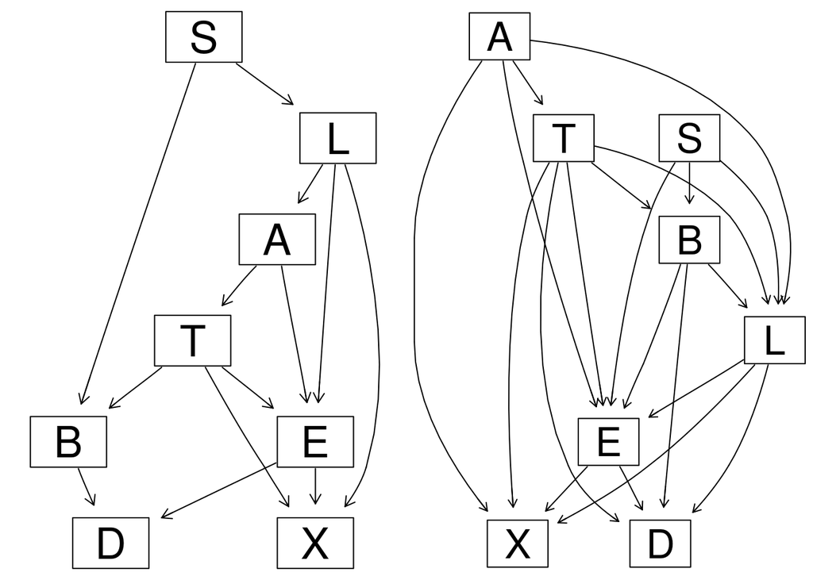

```r
set.seed(123)

graph_a = hc(asia, restart = 10, score = "bde", iss = 10)
graph_b = hc(asia, restart = 10, score = "bde", iss = 100)
par(mar=c(0.5,0.5,0.5,0.5))
par(mfrow=c(1,2))
graphviz.plot(graph_a)
graphviz.plot(graph_b)
```

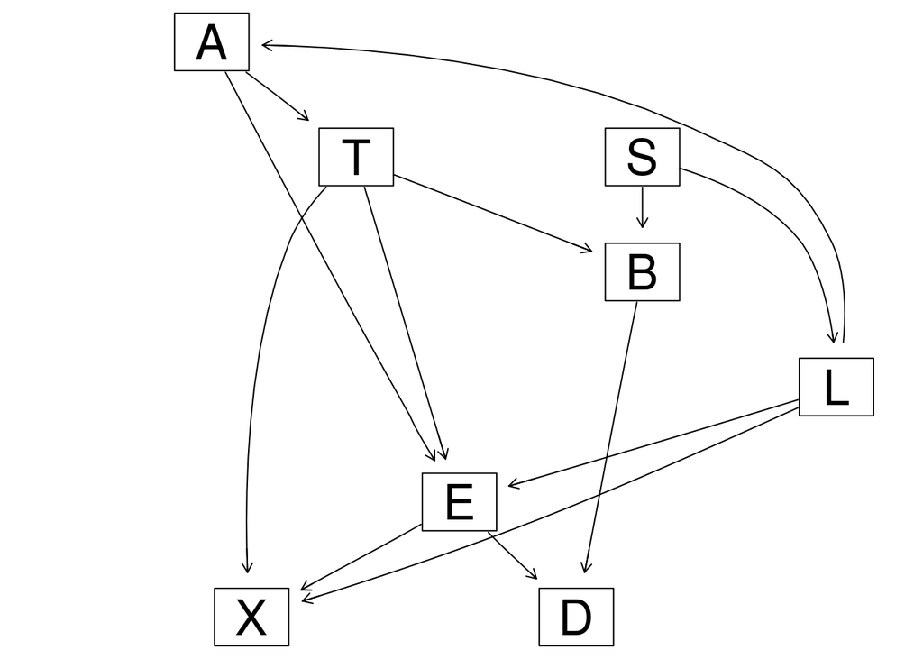

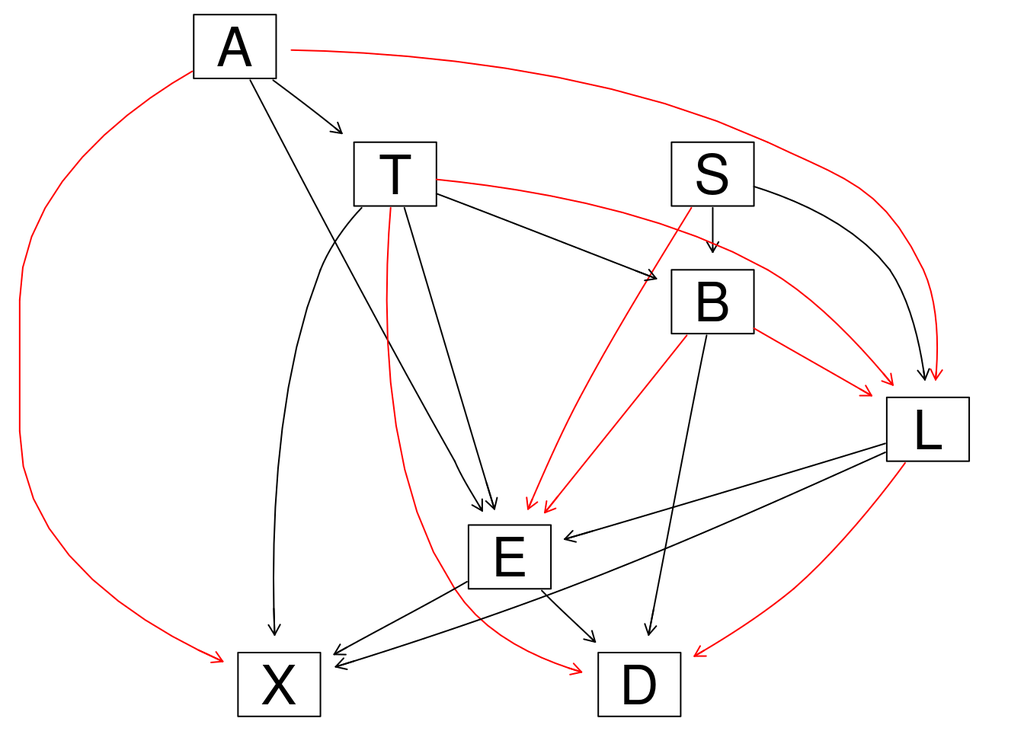

```r
graphviz.compare(graph_a, graph_b)
```

```r
score_a = score(graph_a, asia, type = "bde")
print(score_a)
```

```
## [1] -11132.15
```

```r
score_b = score(graph_b, asia, type = "bde")
print(score_b)
```

```
## [1] -11467.13
```

By changing the parameter iss , we get graphs that are not equivalent. The BDeu score is also different for the two graphs.

# 2

Learn a BN from 80 % of the Asia dataset. The dataset is included in the bnlearn package. To load the data, run data(“asia”). Learn both the structure and the parameters. Use any learning algorithm and settings that you consider appropriate. Use the BN learned to classify the remaining 20 % of the Asia dataset in two classes: S = yes and S = no. In other words, compute the posterior probability distribution of S for each case and classify it in the most likely class. To do so, you have to use exact or approximate inference with the help of the bnlearn and gRain packages, i.e. you are not allowed to use functions such as predict. Report the confusion matrix, i.e. true/false positives/negatives. Compare your results with those of the true Asia BN, which can be obtained by running

dag = model2network(“[A][S][T|A][L|S][B|S][D|B:E][E|T:L][X|E]”).

Hint: You already know two algorithms for exact inference in BNs: Variable elimination and cluster trees. There are also approximate algorithms for when the exact ones are too demanding computationally. For exact inference, you may need the functions bn.fit and as.grain from the bnlearn package, and the functions compile, setEvidence and querygrain from the package gRain. For approximate inference, you may need the functions cpquery or cpdist, prop.table and table from the bnlearn package.

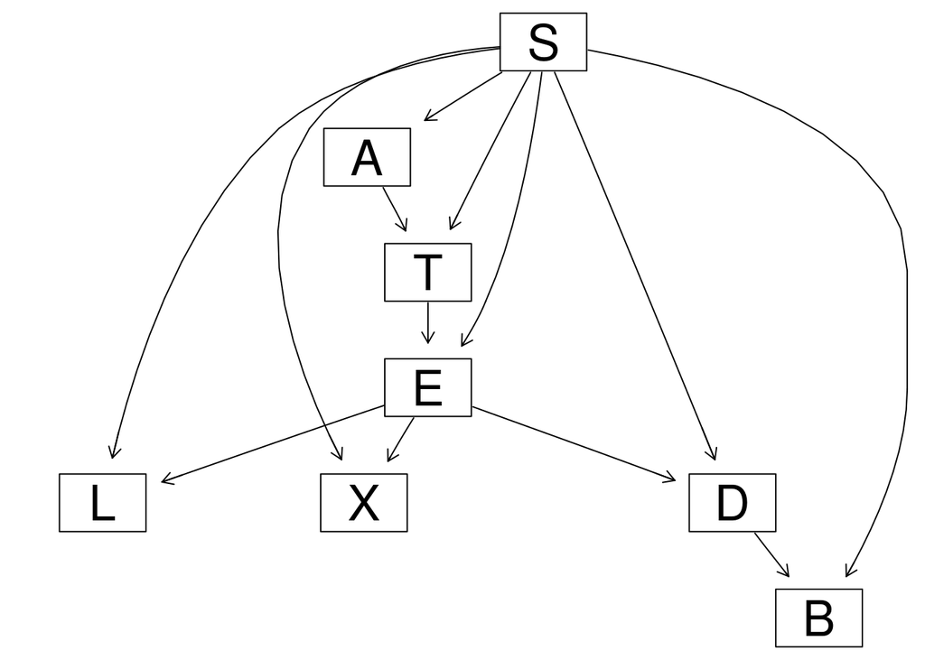

```r
set.seed(123)
n = nrow(asia)
train = asia[1:round(0.8*n),]
test = asia[(round(0.8*n)+1):n,]

#Learn the Structure
tan = tree.bayes(train, training = "S") ###### CHANGE LEARNING METHOD TO IAMB OR HC ##########
#g = hc(asia)
# 8 nodes, only 4 directed arcs, no undirected arcs.
par(mar=c(0,0,0,0))
graphviz.plot(tan)
```

```r
#Learn the parameters
fitted = bn.fit(tan, train, method = "bayes") ###### CHANGE TO MLE METHOD ##############
#convert bn.fit object to grain object:
asiabn = as.grain(fitted)
asiabn = compile(asiabn)
summary(asiabn)
```

```
## Independence network: Compiled: TRUE Propagated: FALSE
##  Nodes : Named chr [1:8] "S" "A" "T" "L" "B" "E" "X" "D"
##  - attr(*, "names")= chr [1:8] "S" "A" "T" "L" ...
##  Number of cliques:                 6
##  Maximal clique size:               3
##  Maximal state space in cliques:    8
```

```r
#querygrain : obtain the conditional distribution of a set of variables - possibly (and typically) given finding (evidence) on other variables.

#Classify the remaining 20% of the Asia dataset
preds = rep(NaN, dim(test)[1])

for(i in 1:dim(test)[1]){
  nodes = c("A","T","L","B","D","E","X")
  states = as.vector(unlist(c(test[i,nodes])))
  evidences = setEvidence(asiabn, nodes, states)
  prob = querygrain(evidences, nodes = "S")
  preds[i] = names(which.max(c(prob$S[1],prob$S[2])))
}
#Report the confusion matrix
preds = as.factor(preds)
confmat = confusionMatrix(preds, test$S)
print(confmat$table)
```

```
##           Reference
## Prediction  no yes
##        no  359 121
##        yes 146 374
```

```r
print(confmat$overall[1])
```

```
## Accuracy
##    0.733
```

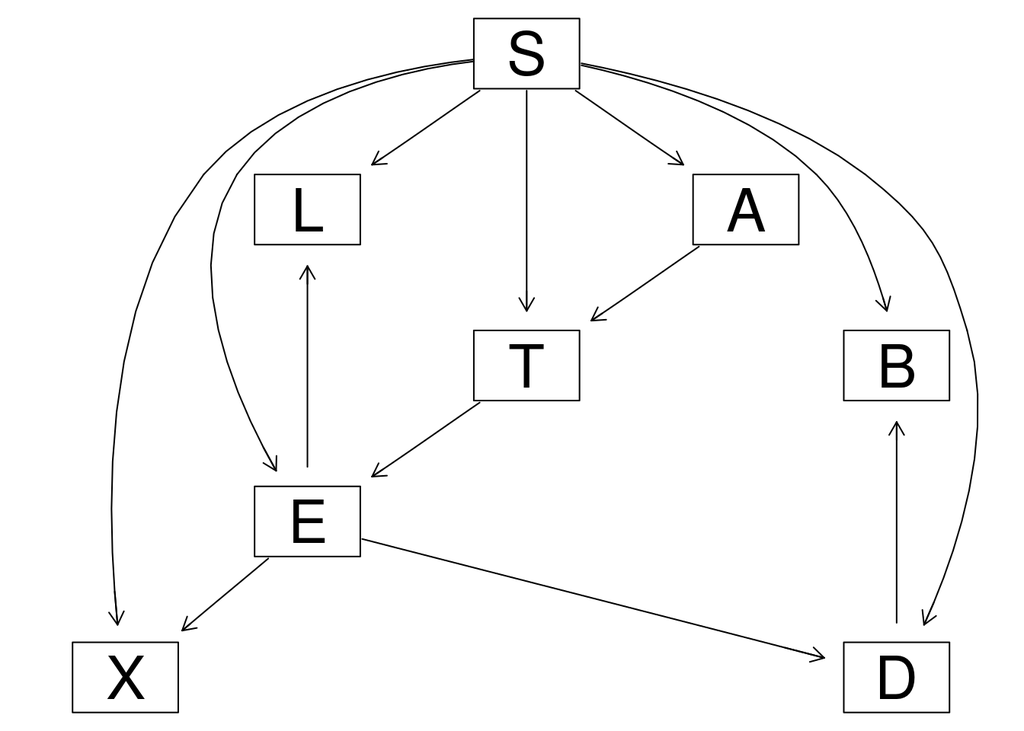

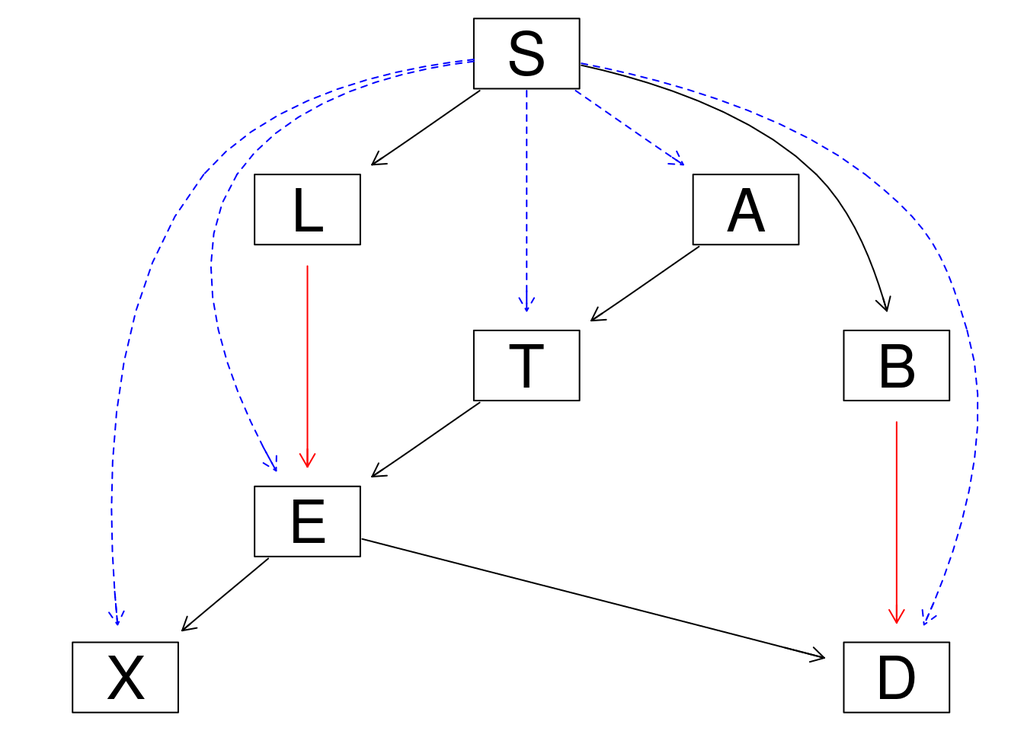

```r
#Compare your results with those of the true Asia BN
dag_true = model2network("[A][S][T|A][L|S][B|S][D|B:E][E|T:L][X|E]")
graphviz.compare(fitted, dag_true)
```

# 3

In the previous exercise, you classified the variable S given observations for all the rest of the variables. Now, you are asked to classify S given observations only for the so-called Markov blanket of S, i.e. its parents plus its children plus the parents of its children minus S itself. Report again the confusion matrix. Hint: You may want to use the function mb from the bnlearn package.

```r
#Learn the parameters
fitted = bn.fit(tan, train, method = "mle")
#Extract the MArkov blanket
Smb = mb(fitted, "S")
#convert bn.fit object to grain object:
mbbn = as.grain(fitted)
mbbn = compile(mbbn)
summary(mbbn)
```

```
## Independence network: Compiled: TRUE Propagated: FALSE
##  Nodes : Named chr [1:8] "S" "A" "T" "L" "B" "E" "X" "D"
##  - attr(*, "names")= chr [1:8] "S" "A" "T" "L" ...
##  Number of cliques:                 6
##  Maximal clique size:               3
##  Maximal state space in cliques:    8
```

```r
#querygrain : obtain the conditional distribution of a set of variables - possibly (and typically) given finding (evidence) on other variables.

#Classify the remaining 20% of the Asia dataset
preds = rep(NaN, dim(test)[1])

for(i in 1:dim(test)[1]){
  nodes = Smb #nodes of interest are the ones in my S-Markov blanket
  states = as.vector(unlist(c(test[i,Smb])))
  evidences = setEvidence(mbbn, nodes, states)
  prob = querygrain(evidences, nodes = "S")
  preds[i] = names(which.max(c(prob$S[1],prob$S[2])))
}
#Report the confusion matrix
preds = as.factor(preds)
confmat = confusionMatrix(preds, test$S)
print(confmat$table)
```

```
##           Reference
## Prediction  no yes
##        no  359 121
##        yes 146 374
```

```r
print(confmat$overall[1])
```

```
## Accuracy
##    0.733
```

# 4

Repeat the exercise (2) using a naive Bayes classifier, i.e. the predictive variables are independent given the class variable. See p. 380 in Bishop’s book or Wikipedia for more information on the naive Bayes classifier. Model the naive Bayes classifier as a BN. You have to create the BN by hand, i.e. you are not allowed to use the function naive.bayes from the bnlearn package.Hint: Check http://www.bnlearn.com/examples/dag/ to see how to create a BN by hand.

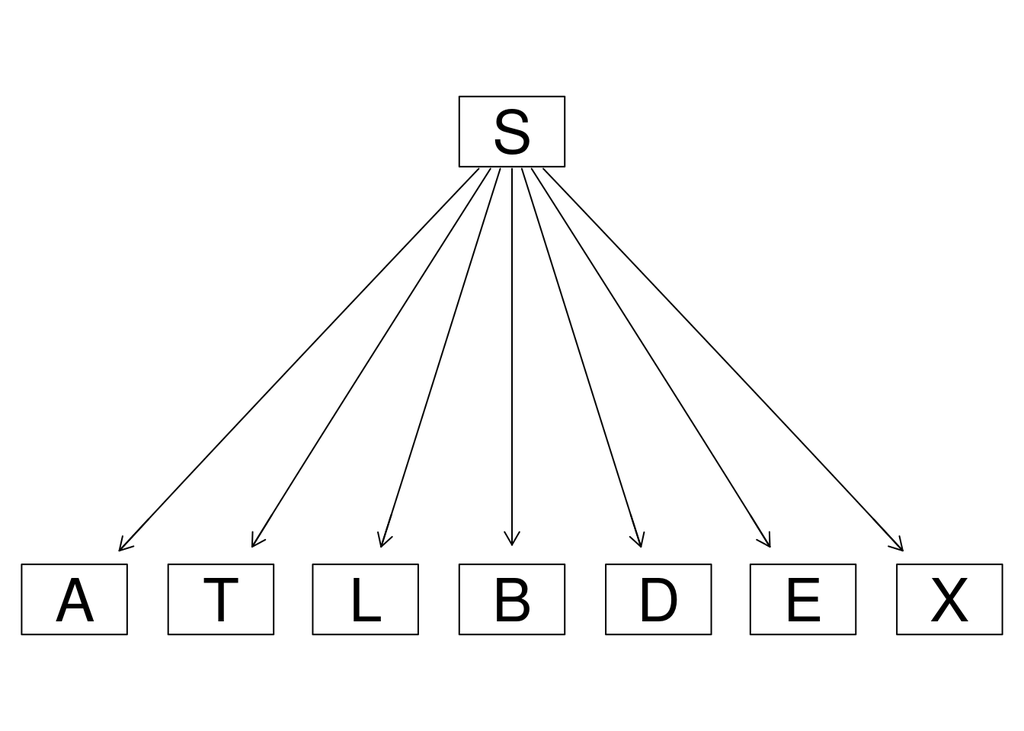

```r
#Creating and empty graph containing all the variables
naiveTree = empty.graph(c("S","A","T","L","B","D","E","X"))
#Manually setting the edges to represent a Naive Bayes Classifier
edges = matrix(c("S","A","S","L","S","T","S","B","S","E","S","X","S","D"),
               ncol = 2, byrow = T, dimnames=list(NULL, c("from","to")))
arcs(naiveTree) = edges
graphviz.plot(naiveTree)
```

```r
fittedBayes = bn.fit(naiveTree, train, method = "mle")
#convert bn.fit object to grain object:
bayesBN = as.grain(fittedBayes)
bayesBN = compile(bayesBN)
summary(bayesBN)
```

```
## Independence network: Compiled: TRUE Propagated: FALSE
##  Nodes : Named chr [1:8] "S" "A" "T" "L" "B" "D" "E" "X"
##  - attr(*, "names")= chr [1:8] "S" "A" "T" "L" ...
##  Number of cliques:                 7
##  Maximal clique size:               2
##  Maximal state space in cliques:    4
```

```r
#querygrain : obtain the conditional distribution of a set of variables - possibly (and typically) given finding (evidence) on other variables.

#Classify the remaining 20% of the Asia dataset
preds = rep(NaN, dim(test)[1])

for(i in 1:dim(test)[1]){
  nodes = c("A","T","L","B","D","E","X")
  states = as.vector(unlist(c(test[i,nodes])))
  evidences = setEvidence(bayesBN, nodes, states)
  prob = querygrain(evidences, nodes = "S")
  preds[i] = names(which.max(c(prob$S[1],prob$S[2])))
}
#Report the confusion matrix
preds = as.factor(preds)
confmat = confusionMatrix(preds, test$S)
print(confmat$table)
```

```
##           Reference
## Prediction  no yes
##        no  389 180
##        yes 116 315
```

```r
print(confmat$overall[1])
```

```
## Accuracy
##    0.704
```

# 5

Explain why you obtain the same or different results in the exercises (2-4).

The results in 2 and 3 are exaclty the same because the structure learned is not influence by the MArkov Blanket since the Markov blanket od S includes all the nodes in the graph. The results in 4 are slightly less accurate because we use a naive approach